# EEC 214 Lecture 3 Notes

Rajeevan Amirtharajah

ramirtha@ucdavis.edu

(c) Rajeevan Amirtharajah, 2026

# Python Initialization

```python
# --------------------------------------------------------------------
# Initialization
# --------------------------------------------------------------------

import matplotlib.pyplot as plt     # MATLAB-style plotting

import numpy as np                  # Numerical methods
from numpy import sqrt, sin, cos, tan, pi, log, e, exp, arctan, arcsin, arccos, log10, log2
from numpy import zeros, ones, linspace, geomspace, logspace
from numpy import real, imag

from scipy import signal            # Signal processing toolbox
```

# Typical Device Parameters

Taken from Sedra and Smith, Microelectronics, 8th ed.

[figure not shown]

Early voltage $|V_{A}| = |V_{A}^{'}|L$

[figure not shown]

# Diode Linear Regulators

**DIODE REGULATORS**

Exploit "ideal" diode behavior, where diode voltage drop approximately independent of diode current:

[figure not shown]

$$V_{out} = V_D \approx 0.6 - 0.7\text{ V} \quad (\text{silicon})$$$$I_{out} = \frac{V_{out}}{R_L}$$

For higher $V_{out}$:

[figure not shown]

$$V_{out} = N \cdot V_D \quad \leftarrow \text{limited to multiples of } 0.6 - 0.7$$$$V_{in} > N \cdot V_D$$

Graphical solution for $V_{out}$:

$$ \begin{aligned} I_{in} &= I_D + I_{out} \quad (\text{KCL}) \\ &= I_s\left(e^{V_D / \frac{nkT}{q}} - 1\right) + \frac{V_D}{R_L} = I_s\left(e^{V_{out} / \frac{nkT}{q}} - 1\right) + \frac{V_{out}}{R_L} \end{aligned} $$

$$n \equiv \text{diode nonideality factor}$$$$I_{in} = \frac{V_{in} - V_{out}}{R_{in}}$$

[figure not shown]

Exact solution:

$$\frac{V_{in} - V_{out}}{R_{in}} = I_s\left(e^{V_{out} / \frac{nkT}{q}} - 1\right) + \frac{V_{out}}{R_L}$$$$\Rightarrow I_s\left(e^{V_{out} / \frac{nkT}{q}} - 1\right) + V_{out}\left(\frac{1}{R_L} + \frac{1}{R_{in}}\right) - \frac{V_{in}}{R_{in}} = 0$$

Iterate / use numerical methods to solve.

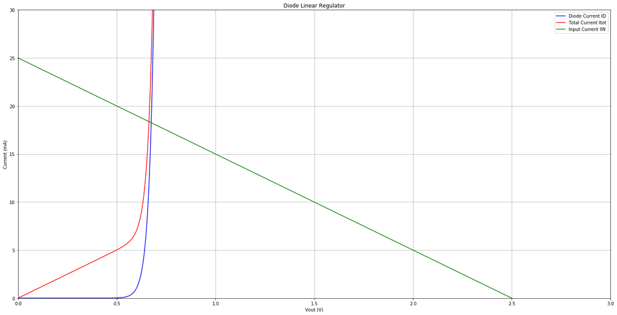

```python
# --------------------------------------------------------------------
# Diode Load-Line Example
# --------------------------------------------------------------------
IS  = 1.0e-13 # Saturation current (A)
VT  = 26e-3   # Thermal voltage (V)
RL  = 1.0e2   # Load resistance (ohms)
n   = 1.0     # Diode nonideality factor
VIN = 2.5     # Input voltage (V)
RIN = 100     # Input resistance (ohms)

VOUT = np.arange(0.0, 2.5, 1e-4) # Output voltage range (V)

# Diode Current
ID = IS*(exp(VOUT/(n*VT)) - 1.0)

# Load Current
IL = VOUT/RL

# Total Current
Itot = ID + IL

# Input Current
IIN = (VIN - VOUT)/RIN

figNum = 1
plt.figure(figNum,figsize=(24,12)) # Figure size in in. x in.
ID_curve,  =  plt.plot(VOUT, ID/1e-3,   'b')
Itot_curve, = plt.plot(VOUT, Itot/1e-3, 'r')
IIN_curve,  = plt.plot(VOUT, IIN/1e-3,  'g')
plt.axis([ 0.0, 3.0, 0.0, 30.0 ]) # Full extent for n = 1.0, VIN = 2.5, RIN = 100, RL = 100
# plt.axis([ 0.0, 1.8, 0.0, 19.0 ]) # Zoomed in on region of interest
plt.grid(True)
plt.xlabel("Vout (V)")
plt.ylabel("Current (mA)")
plt.title("Diode Linear Regulator")
plt.legend([ ID_curve, Itot_curve, IIN_curve ],[ 'Diode Current ID', 'Total Current Itot', 'Input Current IIN'])
plt.show()
```

For high efficiency, want $I_{out} \gg I_D$.

$$\eta = \frac{V_{out} I_{out}}{V_{in} (I_{out} + I_D)} \le \frac{V_{out}}{V_{in}} \quad \text{(worse than linear regulator, potentially)}$$

**Temperature Variation**

Assume diode branch current fixed at $I_D$:

$$I_D \cong I_s e^{V_{out} / \frac{nkT}{q}} \qquad \text{(neglecting reverse current)}$$$$V_{out} = \frac{nkT}{q} \ln\left(\frac{I_D}{I_s}\right) \qquad \frac{dV_{out}}{dT} \approx -2\text{ mV}/^\circ\text{C} \quad (I_s \text{ dominates thermal voltage term})$$

**Zener Regulator**

Operate zener diode in reverse breakdown:

[figure not shown]

$$V_{out} \cong -V_{BR}$$

Zener breakdown does not damage diode

$R_{in}$ chosen to limit $I_D$ below maximum power limit of diode

$$P_{max} \ge \vert{}V_{BR}\vert{} \cdot I_D \qquad I_D = I_{in} - I_{out} = \frac{V_{in} - \vert{}V_{BR}\vert{}}{R_{in}} - \frac{V_{out}}{R_L}$$$$\frac{P_{max}}{\vert{}V_{BR}\vert{}} \ge \frac{V_{in} - \vert{}V_{BR}\vert{}}{R_{in}} - \frac{V_{out}}{R_L} \Rightarrow \frac{P_{max}}{\vert{}V_{BR}\vert{}} + \frac{V_{out}}{R_L} \ge \frac{V_{in} - \vert{}V_{BR}\vert{}}{R_{in}}$$$$R_{in} \ge \frac{V_{in} - \vert{}V_{BR}\vert{}}{\frac{P_{max}}{\vert{}V_{BR}\vert{}} + \frac{\vert{}V_{BR}\vert{}}{R_L}}$$

**Summary**

Diode regulators examples of shunt linear regulators

Efficiency worse than series regulators

$$\eta = \frac{V_{out} \cdot I_{out}}{V_{in} \cdot I_{in}} = \frac{V_{out}}{V_{in}} \cdot \frac{I_{out}}{I_{out} + I_{shunt}}$$

Temperature stability limited by diode temp. coefficient

Very cheap! Diode + resistor

**Emitter-Base Zener Implementation**

[figure not shown]

Base-emitter junction operates in reverse breakdown:

$I_R \equiv$ reverse current

$I_{RA} \equiv$ reverse current near breakdown $\Rightarrow I_{RA} = M I_R$

Multiplication factor $\quad \displaystyle M = \frac{1}{1 - \left(\frac{V_R}{BV}\right)^n}$ $\qquad \qquad \qquad \qquad \qquad \qquad \qquad \qquad \quad \begin{aligned}[t] V_R &\equiv \text{reverse diode voltage} \\ n &\text{ between 3 and 6} \\ BV &\equiv \text{breakdown voltage} \end{aligned}$

$$BV = \frac{\epsilon (N_A + N_D)}{2q N_A N_D} E_{crit}^2 \qquad \qquad \qquad E_{crit} \equiv \text{critical electric field}$$

[figure not shown]